# First Course Ding: Chapter 27

Mediation analysis

The R source for Chapter 27 implements the Baron-Kenny mediation decomposition. It fits one regression for the mediator and one regression for the outcome, then reports:

- the natural direct effect estimate from the treatment coefficient in the outcome model
- the natural indirect effect estimate as the product of the treatment-to-mediator coefficient and the mediator-to-outcome coefficient
- Sobel-style delta-method uncertainty for the indirect effect

This is not a full mediation module in `crabbymetrics`; it is a transparent translation of the chapter’s regression calculation using `OLS` and HC1 covariance summaries.

```python
from pathlib import Path

import matplotlib.pyplot as plt
import numpy as np
import pandas as pd

import crabbymetrics as cm

np.set_printoptions(precision=4, suppress=True)


def repo_root():
    for candidate in [Path.cwd().resolve(), *Path.cwd().resolve().parents]:
        if (candidate / "ding_w_source").exists():
            return candidate
    raise FileNotFoundError("could not locate ding_w_source from the current working directory")


data_dir = repo_root() / "ding_w_source" / "repl"


def standardize_columns(x):
    x = np.asarray(x, dtype=float)
    scale = np.where(x.std(axis=0) > 1e-12, x.std(axis=0), 1.0)
    return (x - x.mean(axis=0, keepdims=True)) / scale


def bk_mediation(z, m, y, x):
    z = np.asarray(z, dtype=float)
    m = np.asarray(m, dtype=float)
    y = np.asarray(y, dtype=float)
    x = np.asarray(x, dtype=float)

    mediator_model = cm.OLS()
    mediator_model.fit(np.column_stack([z, x]), m)
    mediator_summary = mediator_model.summary(vcov="hc1")

    outcome_model = cm.OLS()
    outcome_model.fit(np.column_stack([z, m, x]), y)
    outcome_summary = outcome_model.summary(vcov="hc1")

    z_to_m = float(mediator_summary["coef"][0])
    z_to_m_se = float(mediator_summary["coef_se"][0])
    direct = float(outcome_summary["coef"][0])
    direct_se = float(outcome_summary["coef_se"][0])
    m_to_y = float(outcome_summary["coef"][1])
    m_to_y_se = float(outcome_summary["coef_se"][1])

    indirect = m_to_y * z_to_m
    indirect_se = np.sqrt((m_to_y_se**2) * (z_to_m**2) + (m_to_y**2) * (z_to_m_se**2))

    return pd.DataFrame(
        {
            "estimate": [direct, indirect],
            "se_hc1_delta": [direct_se, indirect_se],
            "t": [direct / direct_se, indirect / indirect_se],
        },
        index=["NDE", "NIE"],
    )
```

## 1 Simulation

The R script uses three data-generating processes to show that the direct-effect estimate is close to normal in simple linear systems, while the product-form indirect-effect estimate can be visibly non-normal.

Each Monte Carlo draw uses $n=200$ independent units with

$$Z_i \sim \operatorname{Bernoulli}(0.5), \qquad X_i \sim N(0, 1),$$

and independent $N(0,1)$ disturbances in the mediator and outcome equations. The fitted mediation model is

$$M_i = \alpha_M + a Z_i + \gamma_M X_i + e_{Mi},
\qquad
Y_i = \alpha_Y + c' Z_i + b M_i + \gamma_Y X_i + e_{Yi}.$$

The reported direct-effect estimate is $\hat c'$. The reported indirect-effect estimate is the product $\hat a \hat b$. The three regimes in the R script differ only in whether the treatment-to-mediator path $a$ and mediator-to-outcome path $b$ are present:

| Regime | Mediator DGP | Outcome DGP | Population NDE | Population NIE |
| --- | --- | --- | --- | --- |
| Indirect path present | $M = Z + X + e_M$ | $Y = Z + M + X + e_Y$ | 1 | 1 |
| No mediator-to-outcome path | $M = Z + X + e_M$ | $Y = Z + X + e_Y$ | 1 | 0 |
| No indirect path | $M = X + e_M$ | $Y = Z + X + e_Y$ | 1 | 0 |

The last two regimes both have zero indirect effect, but for different reasons. In the second, treatment still shifts the mediator and the fitted product is zero because $b=0$. In the third, neither leg of the mediated path is active in the outcome system used by the R script.

```python
def simulate_once(rng, mediator_effect, outcome_mediator_effect, n=200):
    z = rng.binomial(1, 0.5, size=n).astype(float)
    x = rng.normal(size=n)
    m = mediator_effect * z + x + rng.normal(size=n)
    y = z + outcome_mediator_effect * m + x + rng.normal(size=n)
    table = bk_mediation(z, m, y, x[:, None])
    return table["estimate"].to_numpy()


def simulate_regime(seed, mediator_effect, outcome_mediator_effect, n_rep=600):
    rng = np.random.default_rng(seed)
    return np.vstack(
        [
            simulate_once(rng, mediator_effect, outcome_mediator_effect)
            for _ in range(n_rep)
        ]
    )


regimes = {
    "Indirect path present": simulate_regime(2701, 1.0, 1.0),
    "No mediator-to-outcome path": simulate_regime(2702, 1.0, 0.0),
    "No indirect path": simulate_regime(2703, 0.0, 0.0),
}

simulation_summary = []
for label, draws in regimes.items():
    simulation_summary.append(
        {
            "regime": label,
            "mean_NDE": draws[:, 0].mean(),
            "sd_NDE": draws[:, 0].std(ddof=1),
            "mean_NIE": draws[:, 1].mean(),
            "sd_NIE": draws[:, 1].std(ddof=1),
        }
    )

pd.DataFrame(simulation_summary)
```

|  | regime | mean_NDE | sd_NDE | mean_NIE | sd_NIE |
| --- | --- | --- | --- | --- | --- |
| 0 | Indirect path present | 0.996003 | 0.162301 | 0.983461 | 0.159089 |
| 1 | No mediator-to-outcome path | 1.003841 | 0.156351 | -0.001496 | 0.073119 |
| 2 | No indirect path | 0.997264 | 0.141582 | -0.000504 | 0.009662 |

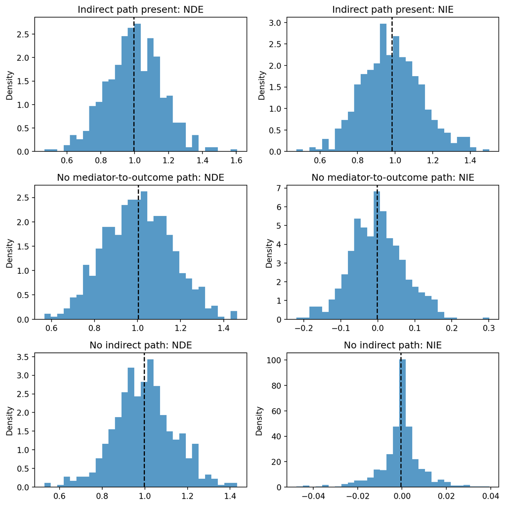

```python
fig, axes = plt.subplots(3, 2, figsize=(9, 9))
for row, (label, draws) in enumerate(regimes.items()):
    axes[row, 0].hist(draws[:, 0], bins=30, density=True, alpha=0.75)
    axes[row, 0].axvline(draws[:, 0].mean(), color="black", linestyle="--")
    axes[row, 0].set_title(f"{label}: NDE")

    axes[row, 1].hist(draws[:, 1], bins=30, density=True, alpha=0.75)
    axes[row, 1].axvline(draws[:, 1].mean(), color="black", linestyle="--")
    axes[row, 1].set_title(f"{label}: NIE")

for ax in axes.ravel():
    ax.set_ylabel("Density")

fig.tight_layout()
```

## 2 JOBS Data

The source R script closes with the JOBS data from the `mediation` package. Here the treatment is job-search training, the mediator is job-search self-efficacy, and the outcome is follow-up depression.

```python
jobs = pd.read_csv(data_dir / "jobsdata.csv")

z = jobs["treat"].to_numpy(dtype=float)
m = jobs["job_seek"].to_numpy(dtype=float)
y = jobs["depress2"].to_numpy(dtype=float)

feature_columns = [
    "econ_hard",
    "depress1",
    "sex",
    "age",
    "occp",
    "marital",
    "nonwhite",
    "educ",
    "income",
]
x = pd.get_dummies(jobs[feature_columns], drop_first=True, dtype=float).to_numpy(dtype=float)
x = standardize_columns(x)

bk_mediation(z, m, y, x)
```

|  | estimate | se_hc1_delta | t |
| --- | --- | --- | --- |
| NDE | -0.036789 | 0.040862 | -0.900318 |
| NIE | -0.013733 | 0.008845 | -1.552634 |

## 3 Implementation Note

This chapter is now executable, but it is still a narrow translation. The R code itself uses the Baron-Kenny product estimator and a Sobel-style variance calculation; it does not implement a general mediation framework with sensitivity analysis, nonparametric bootstrap inference, or alternative identification strategies. Those would be separate library features rather than doc-only translations.